# Learner Engagement in a Cyber Security MOOC

Vivan Kushal Heneger

2026-01-16

```r
install.packages("ProjectTemplate")
library(ProjectTemplate)
create.project("Vivan_MAS8600")
```

# 1. Introduction

Online learning platforms produce a lot of data as a result of interactions, assessments, and participation processes among learners. The analysis of this data will allow getting a chance to interpret how learners participate in course materials and how their participation is connected with the results of the course. Learning analytics is important in deriving meaningful information about such data to aid in evidence-based additions in online education.

The analysis is based on the CRISP-DM (Cross-Industry Standard Process for Data Mining) framework in order to make it systematic and reproducible. CRISP-DM offers a straight-forward outlay and approach to developing the problem understanding into data exploration, preparation, analysis, and interpretation. The framework is used in two cycles of analysis where the results of the first stage can be utilized in the second stage of analysis that is more accurate and narrow.

# 2. CRISP-DM Cycle 1

# 2.1 Business Understanding

CRISP-DM begins with the first stage, which is to define the objective of the analytical purpose and conceptualize the problem in an educational and analytical manner. This step is meant to pose a general question which can be answered with the help of the available data without drawing a firm conclusion.

The main aim of the Cycle 1 is to create the initial knowledge about the learner engagement patterns in the course and to learn how these patterns are associated with the course completion.

The key analytical questions for Cycle 1 are outlined below:

- How do learners engage with course content at a general level?
- What proportion of learners show little or no recorded activity?
- How does overall engagement differ between learners who complete the course and those who do not?
- What limitations or challenges are present in the available data?

# 2.2 Data Understanding (Cycle 1)

This phase focuses on developing a clear understanding of the available datasets before any transformation or modelling is performed. The objective is to examine dataset structure, size, and quality, and to identify any limitations that may affect subsequent analysis.

A summary of the datasets used in this study is provided below:

1. Enrolment datasets
- Contain learner demographic information and enrolment timestamps
- Used to identify learners and course completion status
2. Step activity dataset
- Records learner interactions with individual course steps
- Includes visit and completion timestamps
- Serves as the primary source of engagement data
3. Leaving survey dataset
- Contains responses from learners who exited the course early
- Sample size is relatively small compared to overall enrolment

```r
# Load required data from cache
# Dataset Overview and Basic Exploration
load("cache/raw_data_overview.RData")

library(dplyr)
library(ggplot2)

# Create a simple dataset summary table
dataset_summary <- data.frame(
  Dataset = c(
    "Enrolments (Run 2)",
    "Enrolments (Run 4)",
    "Enrolments (Run 5)",
    "Leaving Survey",
    "Step Activity"
  ),
  Rows = c(
    nrow(enrolments_run2),
    nrow(enrolments_run4),
    nrow(enrolments_run5),
    nrow(leaving_survey),
    nrow(step_activity)
  )
)

dataset_summary
```

```
##              Dataset  Rows
## 1 Enrolments (Run 2)  6488
## 2 Enrolments (Run 4)  3992
## 3 Enrolments (Run 5)  3544
## 4     Leaving Survey    83
## 5      Step Activity 28304
```

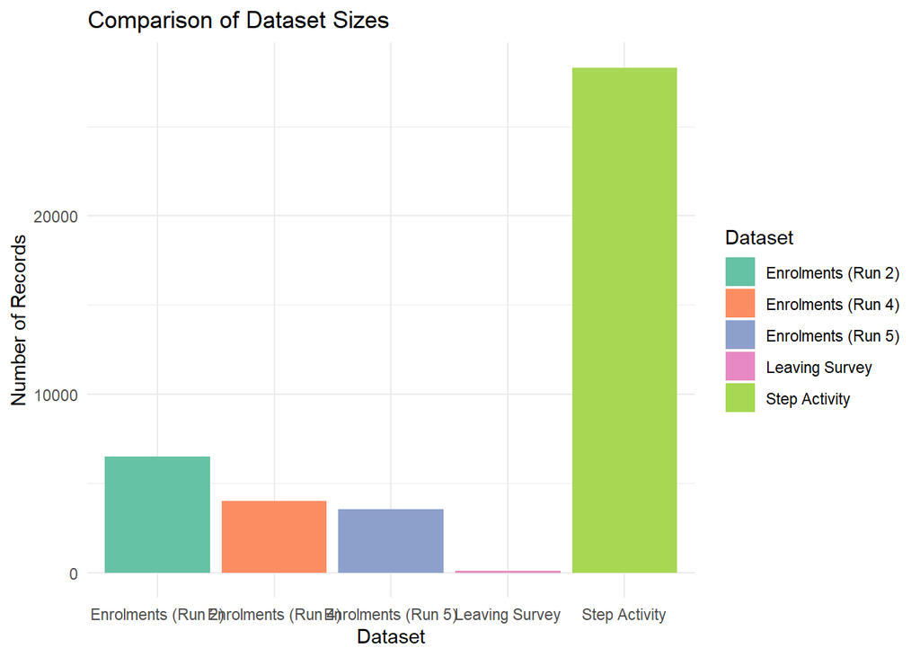

```r
# Plot dataset sizes
p_dataset_sizes <- ggplot(dataset_summary,
                           aes(x = Dataset, y = Rows, fill = Dataset)) +
  geom_col() +
  theme_minimal() +
  labs(
    title = "Comparison of Dataset Sizes",
    x = "Dataset",
    y = "Number of Records"
  ) +
  scale_fill_brewer(palette = "Set2")

# Show plot in PDF / Rmd output
print(p_dataset_sizes)
```

```r
# Save plot to graphs folder
ggsave(
  filename = file.path(graph_dir, "dataset_size_comparison.png"),
  plot = p_dataset_sizes,
  width = 5,
  height = 3,
  dpi = 300
)
```

# Interpretation: Dataset Size Comparison

# CRISP-DM Cycle 1: Exploratory Data Analysis

EDA 1: Enrolment Demographics Overview

This section explores basic demographic characteristics of enrolled learners. The aim is to understand who enrolled in the course before analysing engagement or completion behaviour.

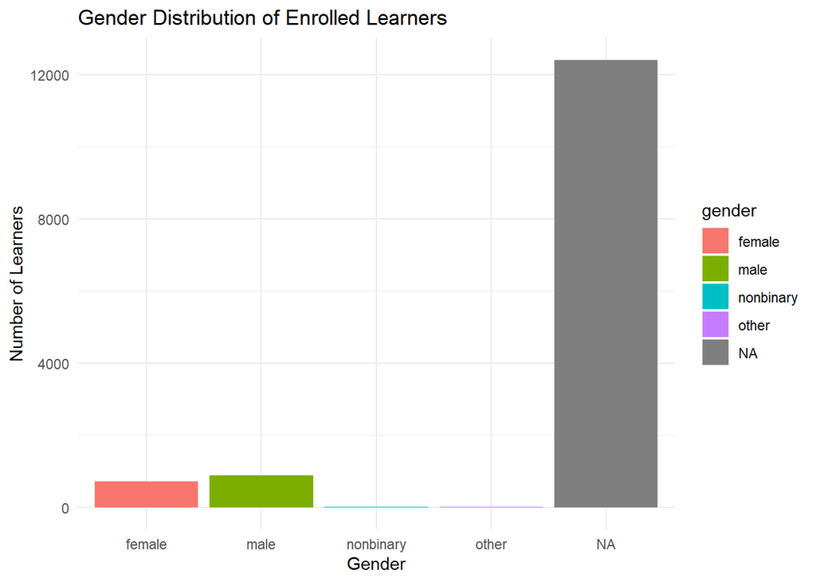

```r
# Gender Distribution
library(ggplot2)

# load cleaned enrolment data
load("cache/enrolments_cleaned.RData")

# create graph directory if not exists
graph_dir <-"D:/vivaannn/Desktop/MASCProject/MASCProject/graphs"
if (!dir.exists(graph_dir)) {
  dir.create(graph_dir, recursive = TRUE)
}

# gender distribution
p_gender <- ggplot(enrolments_all, aes(x = gender, fill = gender)) +
  geom_bar() +
  labs(
    title = "Gender Distribution of Enrolled Learners",
    x = "Gender",
    y = "Number of Learners"
  ) +
  theme_minimal()

# show plot
p_gender
```

```r
# save plot
ggsave(
  filename = file.path(graph_dir, "gender_distribution.png"),
  plot = p_gender,
  width = 6,
  height = 3,
  dpi = 300
)
```

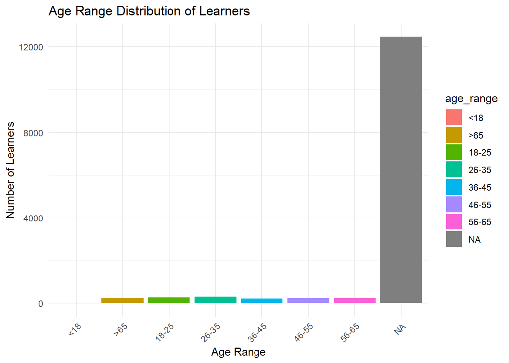

```r
# age range distribution
p_age <- ggplot(enrolments_all, aes(x = age_range, fill = age_range)) +
  geom_bar() +
  labs(
    title = "Age Range Distribution of Learners",
    x = "Age Range",
    y = "Number of Learners"
  ) +
  theme_minimal() +
  theme(axis.text.x = element_text(angle = 45, hjust = 1))

# show plot
p_age
```

```r
# save plot
ggsave(
  filename = file.path(graph_dir, "age_range_distribution.png"),
  plot = p_age,
  width = 9,
  height = 5,
  dpi = 300
)
```

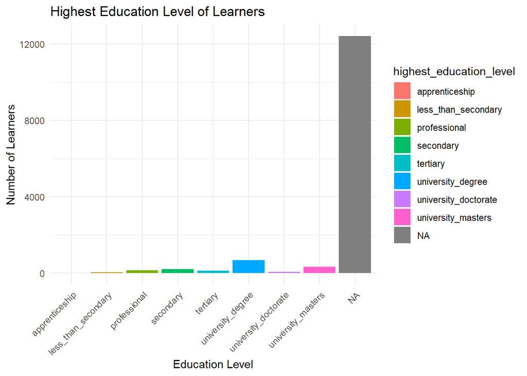

```r
# education level distribution
p_edu <- ggplot(enrolments_all, aes(x = highest_education_level, fill = highest_education_level)) +
  geom_bar() +
  labs(
    title = "Highest Education Level of Learners",
    x = "Education Level",
    y = "Number of Learners"
  ) +
  theme_minimal() +
  theme(axis.text.x = element_text(angle = 45, hjust = 1))

# show plot
p_edu
```

```r
# save plot
ggsave(
  filename = file.path(graph_dir, "education_level_distribution.png"),
  plot = p_edu,
  width = 9,
  height = 5,
  dpi = 300
)
```

# Interpretation: Enrolment Demographics (EDA 1)

Gender Distribution: The gender distribution shows a strong dominance of unspecified or missing values, indicating limited demographic disclosure by learners. Among reported entries, participation is uneven, suggesting that gender-based analysis should be interpreted cautiously. This highlights a data quality limitation rather than an actual imbalance in enrolment.

# EDA 2: Learner Engagement and Course Completion

This section examines how learner engagement relates to course completion. Engagement is measured using step activity, while completion is derived from enrolment records.

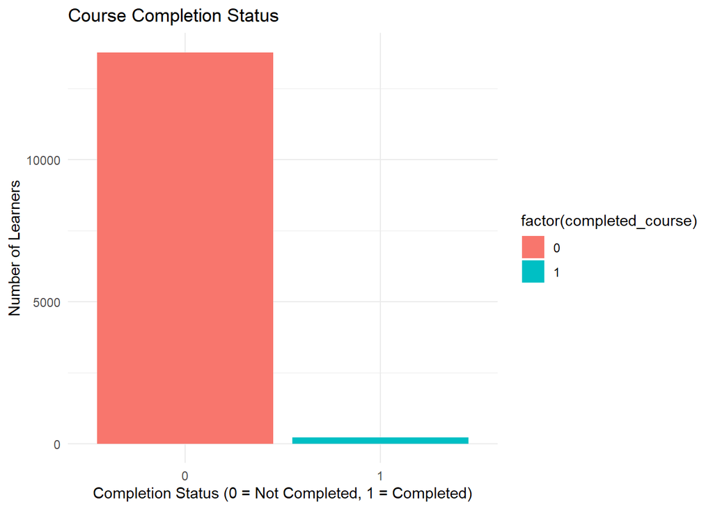

```r
# load Cycle 1 analysis dataset
load("cache/cycle1_analysis_data.RData")

# Course Completion Distribution
library(ggplot2)

# completion distribution
p_completion <- ggplot(cycle1_data, aes(x = factor(completed_course), fill = factor(completed_course))) +
  geom_bar() +
  labs(
    title = "Course Completion Status",
    x = "Completion Status (0 = Not Completed, 1 = Completed)",
    y = "Number of Learners"
  ) +
  theme_minimal()

# show plot
p_completion
```

```r
# save plot
ggsave(
  filename = file.path(graph_dir, "course_completion_distribution.png"),
  plot = p_completion,
  width = 8,
  height = 5,
  dpi = 300
)
```

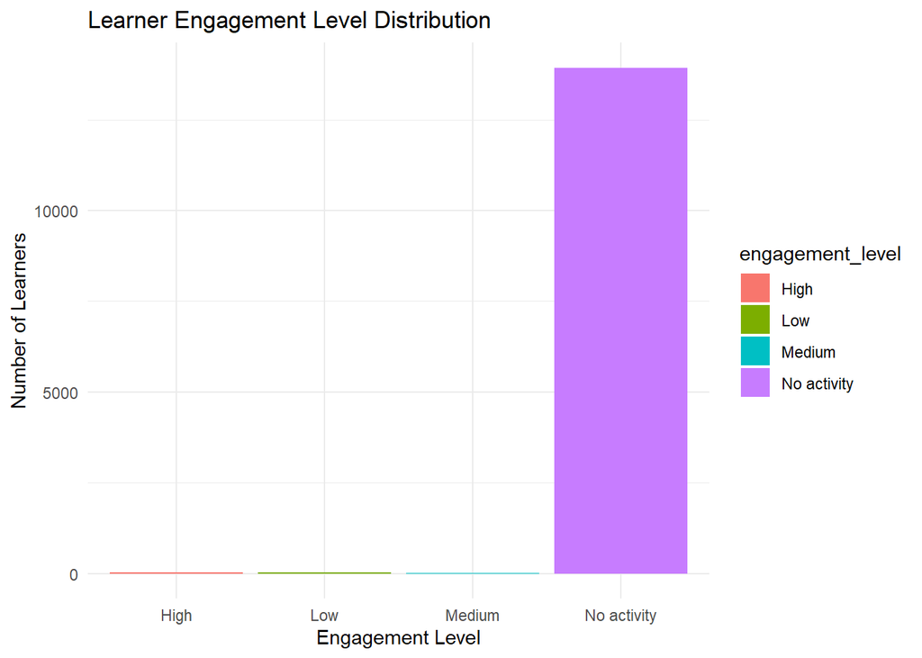

```r
# engagement level distribution
p_engagement <- ggplot(cycle1_data, aes(x = engagement_level, fill = engagement_level)) +
  geom_bar() +
  labs(
    title = "Learner Engagement Level Distribution",
    x = "Engagement Level",
    y = "Number of Learners"
  ) +
  theme_minimal()

# show plot
p_engagement
```

```r
# save plot
ggsave(
  filename = file.path(graph_dir, "engagement_level_distribution.png"),
  plot = p_engagement,
  width = 8,
  height = 5,
  dpi = 300
)
```

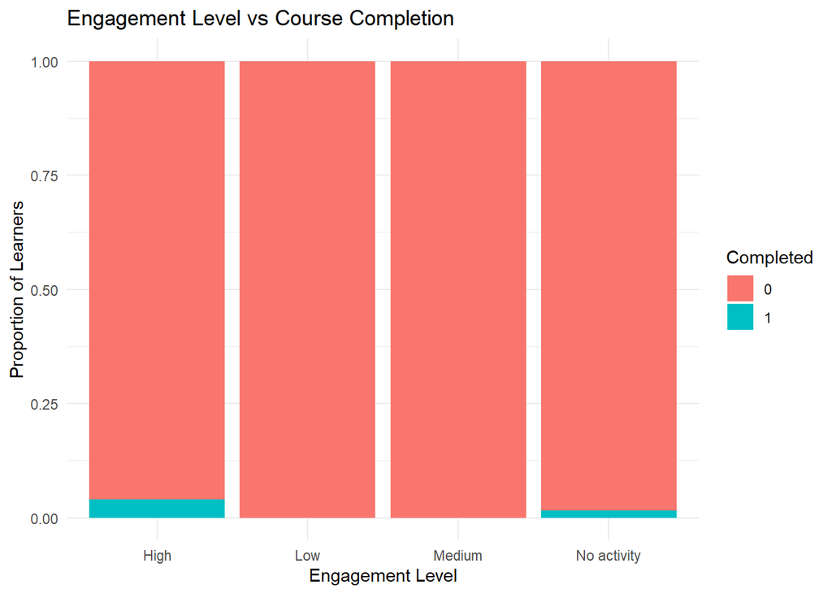

```r
# engagement vs completion
p_engagement_completion <- ggplot(
  cycle1_data,
  aes(x = engagement_level, fill = factor(completed_course))
) +
  geom_bar(position = "fill") +
  labs(
    title = "Engagement Level vs Course Completion",
    x = "Engagement Level",
    y = "Proportion of Learners",
    fill = "Completed"
  ) +
  theme_minimal()

# show plot
p_engagement_completion
```

```r
# save plot
ggsave(
  filename = file.path(graph_dir, "engagement_vs_completion.png"),
  plot = p_engagement_completion,
  width = 8,
  height = 5,
  dpi = 300
)
```